Nidhin Pramod

2023-02-22

## Portfolio optimisation of manually selected assets using GA

For the first part of the project, I have manually chosen 10 assets that are listed on NASDAQ. The emphasis while selecting the assets was to ensure that assets belonging to a specific sector do not dominate the portfolio. This is because, studies have shown that a diverse portfolio gives a better risk adjusted return.

```r
chosenAssets <- c ("AAPL","QCOM","GILD","AVGO","COST","PYPL","WBD","GOOGL","SBUX","VRTX")
```

For the training data the returns of each asset for the year 2019 have been selected.

```r
getSymbols(chosenAssets, src="yahoo", from="2019-01-01", to="2019-12-31")
```

I have then calculated the daily returns for each asset and then merged the result in a dataframe and added the column headers for each columns

```r
myRetData <- data.frame(merge(dailyReturn(AAPL),dailyReturn(QCOM),dailyReturn(GILD)
             ,dailyReturn(AVGO),dailyReturn(COST),dailyReturn(PYPL)
             ,dailyReturn(WBD),dailyReturn(GOOGL),dailyReturn(SBUX)                             ,dailyReturn(VRTX)))

colnames(myRetData) <- chosenAssets
```

In order to determine the optimal weights for a given portfolio, we need to calculate two things, the portfolio returns and the portfolio risk. In the below code snippet I have calculated the mean returns for the 10 assets and the covariance matrix, which has been annualized

```r
meanDailyReturns <-   apply(myRetData,2,mean)
cov_assets  <- cov(myRetData) * 252
```

I observed that using default values of gareal_laCrossover (Local Arithmetic crossover) and gareal_raMutation (Uniform random mutation), has a significant impact on the constraints for weights, i.e the sum of weights should always be 1. In order to reduce the impact I have reset the mutation algorithm to Insertion mutation and crossover algorithm to a Single Point crossover and for selection I have set it to Roulette wheel selection.

```r
gaControl("real-valued" = list(selection = "gareal_rwSelection", #Roulette wheel Selection
                               crossover = "gareal_spCrossover", #Single Point Crossover
                               mutation= "gaperm_ismMutation"))  #Inversion Mutation
```

Next, I have created my own function to generate the initial population for GA.This function will generate 10 weights corresponding to 10 assets for each individual and the sum of weights is equal to 1. This way the initial population always has individuals which always satisfy the constraint

```r
popSize <- 300
num_assets <- 10
initial_population <- function(object) {
  for (r in 1:popSize) {
    chromosome <- runif(n = 10) #generate random chromosome (weights)
    weight <-  chromosome/sum(chromosome) #weights = gene/sum(chromosome weights)
    if (r == 1) {
      initialPop <- rbind(weight)
    }
    else
    {
      initialPop <- rbind(initialPop,weight) #append each row to the matrix
    }
  }
  return(initialPop) #return matrix of population to the GA function
}
```

Next is a function to calulate penalty which will be applied to individuals which do not satisfy the weight constraint. Despite the previous changes, the constraints will eventually get violated due to the crossover operation.

```r
penalty_constraint = function(x) {
  penalty=(sum(x)-1)**2
  return(penalty)
}
```

Next is the fitness function inside which I am calculating the annualized returns based on the weights of each individual chromosome. I am also calculating the portfolio risk which is determined using annualized covariance and the individual asset’s weights. Finally the Sharpe Ratio is calculated which is a measure of risk adjusted return and is a popular method used to get balanced portfolio. When ever an individual violates constraints, I subtract a constant from Sharpe ratio, penalising the solution. This way GA rewards only those solutions that maintain constraint

```r
evalFunc <- function(weights,meanDailyRet,cov_assets) {
  #print(weights)

  annualized_returns <- (sum(weights * meanDailyRet) + 1)^252 - 1
  risk <- sqrt(t(weights) %*% (cov_assets %*% weights))
  sharpe_ratio = annualized_returns/risk
  return(sharpe_ratio - 140 * penalty_constraint(weights))
}
```

Finally we call the GA function and pass our own initial population. The crossover and mutation rates have been adjusted after multiple trials to get the best results.

```r
GA <- ga(type = "real-valued", fitness = function(x) {evalFunc(x, meanDailyReturns, cov_assets)},
         population = initial_population,
         popSize = popSize, maxiter = 2000,
         pcrossover = 0.7,
         lower = rep(0,10),
         upper = rep(1,10),
         pmutation = 0.5,monitor = FALSE
)
#summary(GA)
#plot(GA)
optimal_weights <- as.vector(GA@solution)
cat("Sum of weights ",sum(optimal_weights))
```

```
## Sum of weights  1
```

```r
calcReturns <- function(weights,meanDailyRet) {
  annualized_returns <- (sum(weights * meanDailyRet) + 1)^252 - 1
  return(annualized_returns)
}

calcRisk <- function(weights,cov_asset) {
  risk <- sqrt(t(weights) %*% (cov_asset %*% weights))
  return(risk)
}


GA_returns <- calcReturns (optimal_weights,meanDailyReturns)
GA_risk <-  calcRisk (optimal_weights,cov_assets)
cat("GA returns is", GA_returns, "GA risk is", GA_risk, "GA Sharpe ratio is",GA@fitnessValue)
```

```
## GA returns is 0.4985511 GA risk is 0.1522741 GA Sharpe ratio is 3.274038
```

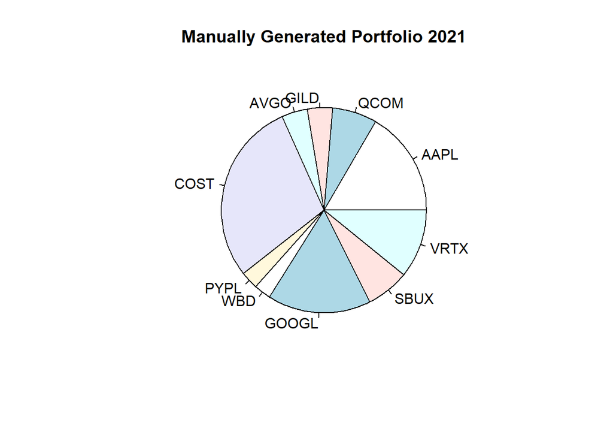

```r
pie(optimal_weights, labels = chosenAssets, main="Manually Generated Portfolio 2021")
```

Finally we can observe the portfolio allocation based on the weights determined using GA.

## Comparison with evenly weighted and Randomly generated weights

I have generated even weights for 10 assets and then calcuted the returns and risk for the portfolio.

```r
even_weights <- rep(0.1,10)
evenlyGen_returns <- calcReturns (even_weights,meanDailyReturns)
evenlyGen_risk <-  calcRisk (even_weights,cov_assets)
cat("Evenly generated portfolio returns is", evenlyGen_returns, "risk is", evenlyGen_risk, "Sharpe ratio is",evenlyGen_returns/evenlyGen_risk)
```

```
## Evenly generated portfolio returns is 0.4296277 risk is 0.158198 Sharpe ratio is 2.71576
```

Next I have randomly generated weights 20 times and calculated their average return and risk.

```r
for (r in 1:20) {
  chromosome <- runif(n = 10) #generate random chromosome (weights)
  random_weight <-  chromosome/sum(chromosome) #weights = gene/sum(chromosome weights)
  random_returns <- calcReturns (random_weight,meanDailyReturns)
  random_risk <-  calcRisk (random_weight,cov_assets)
  if (r==1){
    random_ret_v <- c()
    random_risk_v <- c()
    random_ret_v <- random_returns
    random_risk_v <- random_risk
  }
  else{
  random_ret_v <- append(random_ret_v,random_returns) #append returns to a vector
  random_risk_v <- append(random_risk_v,random_risk) #append risk to a vector
  }
}
avg_random_returns <- mean(random_ret_v)
avg_random_risk <- mean(random_risk_v)
avg_sharpe_ratio <- avg_random_returns/avg_random_risk
cat("Randomly generated portfolio returns is", avg_random_returns, "risk is", avg_random_risk, "Sharpe ratio is",avg_sharpe_ratio)
```

```
## Randomly generated portfolio returns is 0.4318153 risk is 0.1601776 Sharpe ratio is 2.695854
```

Finally we have a scatter plot which shows the difference in performance of each of these methods. We can clearly observe that with a return value of GA clearly outperforms evenly weighted portfolio and Randomly generated portfolio.

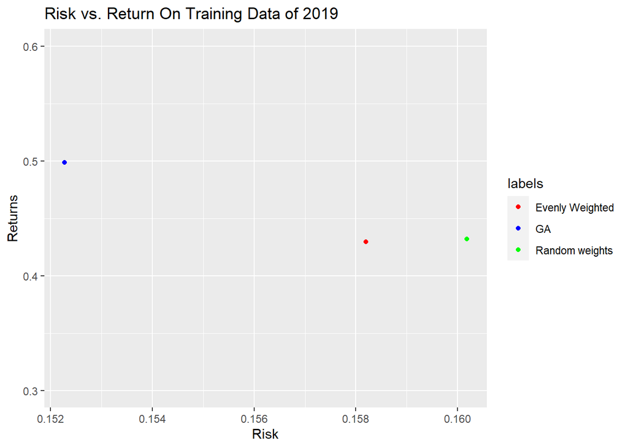

```r
labels <- c("GA","Evenly Weighted","Random weights")
colors <- c("red", "blue", "green")
ggplot() +
  geom_point(aes(x = c(GA_risk,evenlyGen_risk,avg_random_risk),
                 y = c(GA_returns,evenlyGen_returns,avg_random_returns),
                 color = labels)) +
  scale_color_manual(values = colors) +
  labs(x = "Risk", y = "Returns",
       title = "Risk vs. Return On Training Data of 2019") +
  scale_y_continuous(limits = c(0.3, 0.6))
```

## Comparison of GA performance on Unseen Data

For the testing data I have got the asset returns between the period 1-Mar-2020 to 31-Dec-2020. Then I have calculated the daily returns and stored it as a dataframe. After that I have calculated the mean daily returns for each of those assets. Finally have calculated the covariance matrix and annualized.

```r
getSymbols(chosenAssets, src="yahoo", from="2020-03-01", to="2020-12-31")
myRetData2 <- data.frame(merge(dailyReturn(AAPL),dailyReturn(QCOM),dailyReturn(GILD)
                        ,dailyReturn(AVGO),dailyReturn(COST),dailyReturn(PYPL)
                        ,dailyReturn(WBD),dailyReturn(GOOGL),dailyReturn(SBUX)
                        ,dailyReturn(VRTX)))
colnames(myRetData2) <- chosenAssets
meanDailyReturns2 <-   apply(myRetData2,2,mean)
cov_assets2  <- cov(myRetData2) * 252
```

Next I use the optimal weights determined on training data using GA to calculate the returns, risk and Sharpe Ratio.

```r
future_returns <- calcReturns (optimal_weights,meanDailyReturns2)
future_risk <-  calcRisk (optimal_weights,cov_assets2)
cat("Returns for future data using optimal weights is", future_returns, "risk is", future_risk, "Sharpe ratio is",future_returns/future_risk)
```

```
## Returns for future data using optimal weights is 0.6083832 risk is 0.3412178 Sharpe ratio is 1.782976
```

Subsequently I calculated the returns and risk on evenly weighted testing data and randomly generated portfolio weights.

```r
#Evenly generated weights portfolio returns on testing set
evenlyGen_fut_returns <- calcReturns (even_weights,meanDailyReturns2)
evenlyGen_fut_risk <-  calcRisk (even_weights,cov_assets2)
cat("Evenly generated portfolio returns is", evenlyGen_fut_returns, "risk is", evenlyGen_fut_risk, "Sharpe ratio is",evenlyGen_fut_returns/evenlyGen_fut_risk)
```

```
## Evenly generated portfolio returns is 0.652836 risk is 0.3645765 Sharpe ratio is 1.79067
```

```r
#Randomly generated weights portfolio returns on testing set
for (r in 1:5) {
  chromosome <- runif(n = 10) #generate random chromosome (weights)
  random_weight <-  chromosome/sum(chromosome) #weights = gene/sum(chromosome weights)
  random_returns <- calcReturns (random_weight,meanDailyReturns2)
  random_risk <-  calcRisk (random_weight,cov_assets2)
  if (r==1){
    random_ret_v_f <- c()
    random_risk_v_f<- c()
    random_ret_v_f <- random_returns
    random_risk_v_f <- random_risk
  }
  else{
    random_ret_v_f <- append(random_ret_v,random_returns) #append returns to a vector
    random_risk_v_f <- append(random_risk_v,random_risk) #append risk to a vector
  }
}
avg_random_returns_f <- mean(random_ret_v_f)
avg_random_risk_f <- mean(random_risk_v_f)
avg_sharpe_ratio_f <- avg_random_returns/avg_random_risk
cat("Randomly generated portfolio returns is", avg_random_returns_f, "risk is", avg_random_risk_f, "Sharpe ratio is",avg_sharpe_ratio_f)
```

```
## Randomly generated portfolio returns is 0.4369052 risk is 0.1700478 Sharpe ratio is 2.695854
```

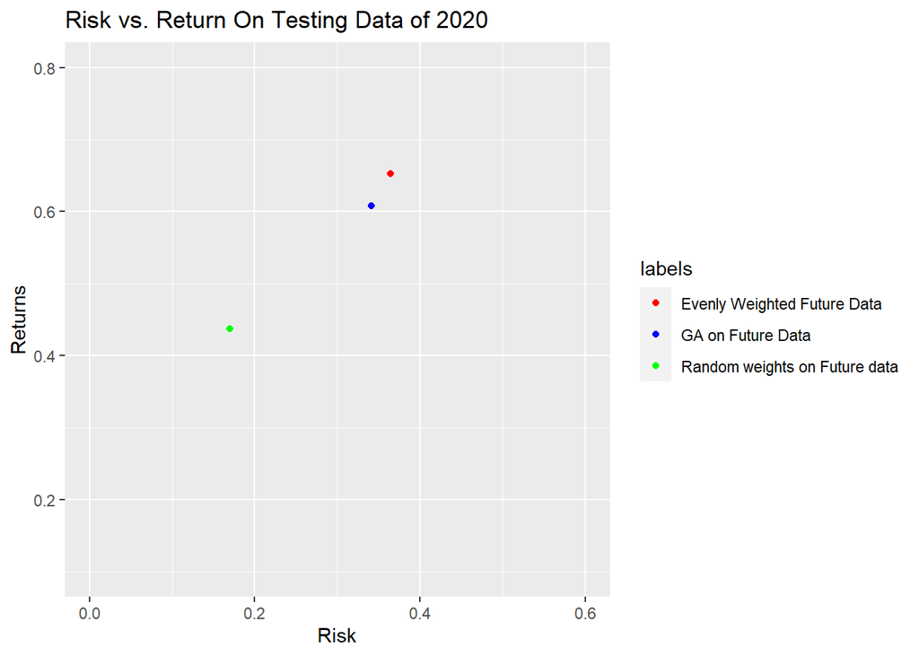

```r
labels <- c("GA on Future Data","Evenly Weighted Future Data","Random weights on Future data")
colors <- c("red", "blue", "green")
ggplot() +
  geom_point(aes(x = c(future_risk,evenlyGen_fut_risk,avg_random_risk_f),
                 y = c(future_returns,evenlyGen_fut_returns,avg_random_returns_f),
                 color = labels)) +
  scale_color_manual(values = colors) +
  labs(x = "Risk", y = "Returns",
       title = "Risk vs. Return On Testing Data of 2020") +
  scale_x_continuous(limits = c(0.0, 0.6)) +
  scale_y_continuous(limits = c(0.1, 0.8))
```

## Experimenting with differently balanced Portfolios

Here I have tried to experiment with portfolio that lie on the extremes. To start with I have a fitness function that emphasises on maximizing the risk. This fitness function does not take into account the returns of the portfolio. I have also implemented a penalty function for any individual that does not satisfy the constraints

```r
riskFocused <- function(weights,cov_assets) {
  risk <- sqrt(t(weights) %*% (cov_assets %*% weights))
  return(risk - 100 * penalty_constraint(weights))
}
```

Next I have a created a fitness function which tries to minimize the risks, this is called a minimum variance portfolio. In this case, the penalty adds a constant to the function so that the GA rewards only those individuals that satisfy the constraints and have a lower fitness value.

```r
LowRisk <- function(weights,cov_assets) {
  #weights <-  chromosome/sum(chromosome)
  risk <- sqrt(t(weights) %*% (cov_assets %*% weights))
  return(risk + 100 * penalty_constraint(weights))
}
```

Next I have fitness function that only tries to maximize the returns and does not take into to account the risk. This function is also having a penalty to penalize individuals that do not satisfy the constraints.

```r
maxReturns <- function(weights,meanDailyRet) {
  annualized_returns <- (sum(weights * meanDailyRet) + 1)^252 - 1
  return(annualized_returns - 100 * penalty_constraint(weights))
}
```

Finally I have another fitness function where the function gives different weights to returns and risk when trying to calculate the Sharpe Ratio. The returns is multiplied with a constant X and the risk is multiplied with (1-X). This gives more importance to returns and less importance to risk

```r
differently_weighted <- function(weights,meanDailyRet,cov_assets) {
  priority_constant <- 0.7
  annualized_returns <-  (sum(weights * meanDailyRet) + 1)^252 - 1
  annualized_returns <- annualized_returns * priority_constant
  risk <-  sqrt(t(weights) %*% (cov_assets %*% weights))
  risk <- risk * (1-priority_constant)
  sharpe_ratio = annualized_returns/risk
  return(sharpe_ratio - 100 * penalty_constraint(weights))
}
```

Next we have the GA implementation for each of those functions. One key thing here is the third GA function has a “-ve” sign in the fitness function, this implies that we are trying to minimize the function.

```r
# GA for extremes
#Case 1 : Portfolio that emphasises only on maximumizing returns
GA <- ga(type = "real-valued", fitness = function(x) {maxReturns(x, meanDailyReturns)},
         population = initial_population,
         popSize = popSize, maxiter = 1000,
         pcrossover = 0.7,
         lower = rep(0,10),
         upper = rep(1,10),
         pmutation = 0.5,monitor = FALSE
)
#summary(GA)
#plot(GA)
print(sum(GA@solution))
```

```
## [1] 1
```

```r
wt_max_rt <- as.vector(GA@solution)
max_rt_ret <- GA@fitnessValue
max_rt_risk <- calcRisk (wt_max_rt,cov_assets)
cat("Portfolio that only cares about Maximizing returns has returns", max_rt_ret)
```

```
## Portfolio that only cares about Maximizing returns has returns 0.5869911
```

```r
cat("Risk in this case is",max_rt_risk)
```

```
## Risk in this case is 0.190599
```

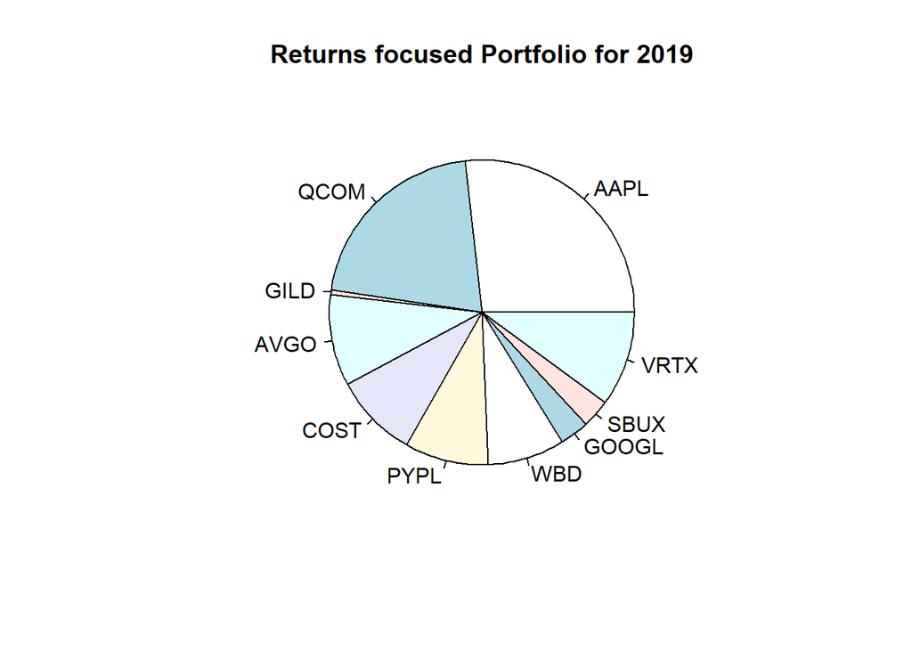

```r
pie(wt_max_rt, labels = chosenAssets, main="Returns focused Portfolio for 2019")
```

```r
#Case 2: Portfolio that emphasizes only on maximizing risk
#Here the fitness function tries to maximize the risk
GA <- ga(type = "real-valued", fitness = function(x) {riskFocused(x, cov_assets)},
         population = initial_population,
         popSize = popSize, maxiter = 1000,
         pcrossover = 0.7,
         lower = rep(0,10),
         upper = rep(1,10),
         pmutation = 0.5,monitor = FALSE
)
#summary(GA)
#plot(GA)
print(sum(GA@solution))
```

```
## [1] 1
```

```r
wt_max_rsk <- as.vector(GA@solution)
max_rsk_rt <- calcReturns (wt_max_rt,meanDailyReturns)
max_rsk_rsk <- GA@fitnessValue
cat("Portfolio that only cares about Maximizing risk has risk of", max_rsk_rsk)
```

```
## Portfolio that only cares about Maximizing risk has risk of 0.2100532
```

```r
cat("Returns in this case is",max_rsk_rt)
```

```
## Returns in this case is 0.5869911
```

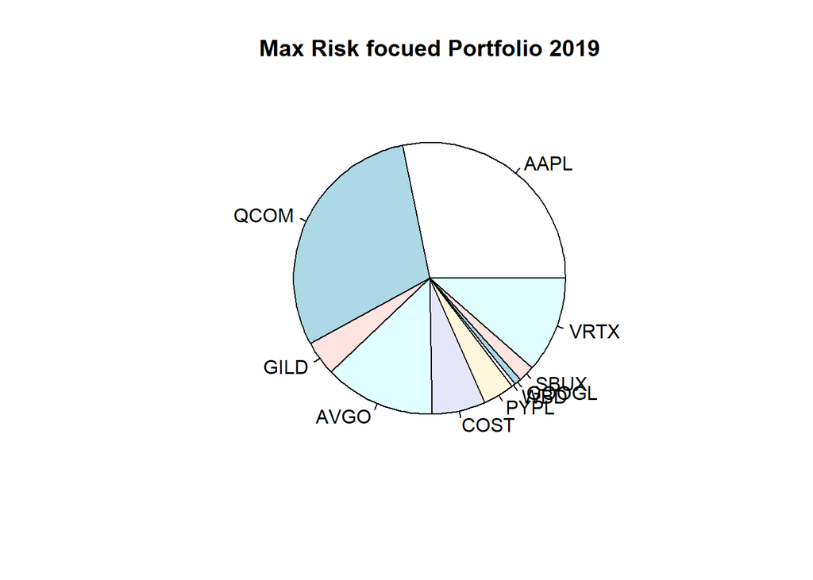

```r
pie(wt_max_rsk, labels = chosenAssets, main="Max Risk focued Portfolio 2019")
```

```r
#Case 3 Portfolio that emphasizes only on minimizing risk
#Here the fitness function tries to minimize the risk

GA <- ga(type = "real-valued", fitness = function(x) -{LowRisk(x, cov_assets)},
         population = initial_population,
         popSize = popSize, maxiter = 1000,
         pcrossover = 0.7,
         lower = rep(0,10),
         upper = rep(1,10),
         pmutation = 0.5,monitor = FALSE
)
#summary(GA)
#plot(GA)
print(sum(GA@solution))
```

```
## [1] 1
```

```r
wt_low_rsk <- as.vector(GA@solution)
low_rsk_ret <- calcReturns (wt_low_rsk,meanDailyReturns)
low_rsk_rsk <- GA@fitnessValue
cat("Portfolio that only cares about Mimizing risk has risk of", low_rsk_rsk)
```

```
## Portfolio that only cares about Mimizing risk has risk of -0.1421083
```

```r
cat("Returns in this case is",low_rsk_ret)
```

```
## Returns in this case is 0.3704297
```

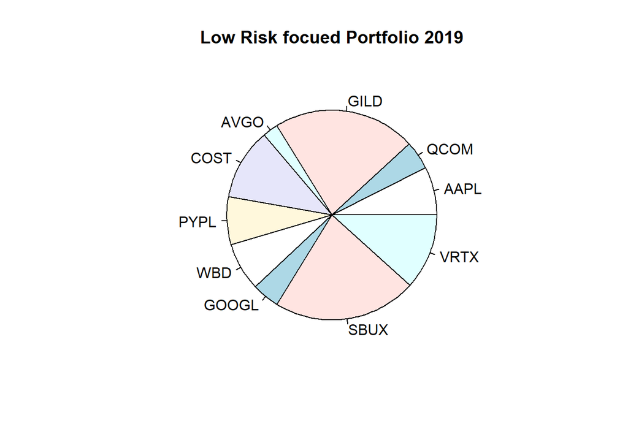

```r
pie(wt_low_rsk, labels = chosenAssets, main="Low Risk focued Portfolio 2019")
```

```r
#Low risk= low returns as well

#Case 4 differently weighted return and risk calculation
#The fitness function gives 70% weightage to  returns and 30% to  risk
GA <- ga(type = "real-valued", fitness = function(x) {differently_weighted(x,meanDailyReturns, cov_assets)},
         population = initial_population,
         popSize = popSize, maxiter = 1000,
         pcrossover = 0.7,
         lower = rep(0,10),
         upper = rep(1,10),
         pmutation = 0.5,monitor = FALSE
)
#summary(GA)
#plot(GA)
print(sum(GA@solution))
```

```
## [1] 0.9992903
```

```r
wt_diff_wt <- as.vector(GA@solution)
diff_wt_ret <- calcReturns (wt_diff_wt,meanDailyReturns)
diff_wt_risk <- calcRisk (wt_diff_wt,cov_assets)
cat("Portfolio that gives different weightage to returns and risk has returns of", diff_wt_ret)
```

```
## Portfolio that gives different weightage to returns and risk has returns of 0.5655297
```

```r
cat("Risk in this case is",diff_wt_risk)
```

```
## Risk in this case is 0.1525082
```

[figure not shown]

```r
pie(wt_low_rsk, labels = chosenAssets, main="Different weighted Portfolio 2019")
```

Now we try to compare the performances of these portfolios at different extremes with the performance of a balanced portfolio

[figure not shown]

```r
labels <- c("Balanced GA","Max Return GA","Max Risk GA","Low Risk GA","Different weighted GA")
colors <- c("red", "blue", "green", "purple", "orange")
ggplot() +
  geom_point(aes(x = c(GA_risk,max_rt_risk,max_rsk_rsk,low_rsk_rsk,diff_wt_risk),
                 y = c(GA_returns,max_rt_ret,max_rsk_rt,low_rsk_ret,diff_wt_ret),
                 color = labels)) +
  scale_color_manual(values = colors) +
  labs(x = "Risk", y = "Returns",
       title = "Risk vs. Return On Testing Data of 2020") +
  scale_x_continuous(limits = c(-0.2, 0.4)) +
  scale_y_continuous(limits = c(0.3, 0.8))
```

## Selecting assets using GA

For this problem I have chosen 90 assets initially from NASDAQ-100 list. And as suggested in the lab exercise, I have used an efficient way to calculating and merging the daily returns and merging them in a dataframe. After that I have caluclated the Mean returns values and covariance of these assets. The timeframe considered is same as the initial training data (2019).

```r
nasdaq100 <- c("AAPL","MSFT","GOOG","GOOGL","AMZN","TSLA","NVDA","META","ASML","AVGO","PEP",
               "COST","AZN","CSCO","TMUS","ADBE","NFLX","CMCSA","TXN","QCOM","AMD","HON","AMGN",
               "SBUX","PDD","INTU","INTC","GILD","AMAT","ADP","BKNG","ADI","PYPL","MDLZ","ISRG",
               "REGN","JD","VRTX","LRCX","MU","CSX","MRNA","CHTR","ATVI","MELI",
               "KLAC","SNPS","MAR","MNST","ORLY","CDNS","PANW","KDP","NXPI","ADSK","KHC","MCHP",
               "AEP","FTNT","CTAS","DXCM","BIIB","PAYX","IDXX","EXC","ROST","ODFL","MRVL","WDAY",
               "LULU","XEL","WBD","CTSH","DLTR","BKR","WBA","EA","CSGP","ILMN","FAST",
               "VRSK","EBAY","TEAM","PCAR","FANG",
               "ANSS","ZS","SIRI","CPRT","WBD")

Assets = lapply(nasdaq100, function(sym) {
  dailyReturn(na.omit(getSymbols(sym, src="yahoo", from="2019-01-01", to="2019-12-31", auto.assign=FALSE)))
})

do.call(merge.xts, Assets)

NasdaqRet <- data.frame(Assets)

colnames(NasdaqRet) <- nasdaq100

#Mean Daily Returns for each asset
nsdqMeanDlyRet <-   apply(NasdaqRet,2,mean)
cov_nsdq  <- cov(NasdaqRet) * 252
```

Next I have tried to calculate the top performing assets initially without using GA, but just sorting the 90 assets based on their performance and picking the top 10

```r
calcAnnual <-  function(x) {
  prod(1+x)^252 - 1
}
res <- unlist((lapply(nsdqMeanDlyRet, calcAnnual)))
res <-  sort(res, decreasing = TRUE)
print(res[1:10])
```

```
##       AMD      LRCX      MELI      KLAC      DXCM       PDD      LULU      AMAT
## 1.9205871 1.3534253 1.2747530 1.1470954 1.0653526 1.0569663 1.0423951 1.0332145
##      ASML      CPRT
## 0.9887117 0.9833863
```

```r
init_population <- function(object) {
  print("Here to get pop")
  for (r in 1:popSize) {
    #generate 10 random numbers between 1 - 90 with no duplicates
    random_assets <-sample(1:length(Assets),10)
    empty_port <- rep(0,length(Assets)) #empty vector with just ones
    chosen<- replace(empty_port,random_assets,1)#replace 10 positions randomly with 1
    if (r == 1) {
      initialPop <- rbind(chosen)
    }
    else
    {
      initialPop <- rbind(initialPop,chosen) #append each row to the matrix
    }
  }
  return(initialPop) #return matrix of population to the GA function
}
```

Next I have a function to check for constraint violation and penalizing the individual.

```r
check_numOnes <- function(x) {
  if (sum(x) != 10 ) {
    return(500)
  }
  else{
    return(0)
  }
}
```

For my fitness function I have used the selection criteria as annualized returns. Annualaized return for each asset is calculated using formula: prod(1 + Ra)^(scale/n) - 1 where scale is the number of periods in a year, for days it is 252.

```r
nsdq_fitness <- function(chosen_assets,nsdqMeanDlyRet) {
  annualized_returns <- prod(1+nsdqMeanDlyRet[chosen_assets==1])^252 - 1
  return(annualized_returns - 100 * check_numOnes(chosen_assets))
}
```

Next I am modifying the default mutation mechanism so that the mutation does not have an impact on the constraint

```r
gaControl("binary" = list(mutation= "gaperm_simMutation"))  #Inversion Mutation
```

Finally I have the GA and below are the assets chosen by using the genetic algorithm

```r
GA <- ga(type = "binary", fitness = function(x) {nsdq_fitness(x, nsdqMeanDlyRet)},
         population = init_population, nBits=90,
         popSize = popSize, maxiter = 100,
         pcrossover = 0.7,
         pmutation = 0.5,monitor = FALSE
)
```

```
## [1] "Here to get pop"
```

```r
#summary(GA)
#plot(GA)
print(sum(GA@solution))
```

```
## [1] 28
```

```r
ga_chosen_bin <- GA@solution
ga_chosen_assets <- nasdaq100[ga_chosen_bin==1]
print(ga_chosen_assets)
```

```
##  [1] "AAPL" "TSLA" "NVDA" "META" "ASML" "COST" "QCOM" "AMD"  "HON"  "SBUX"
## [11] "ADP"  "JD"   "MU"   "MRNA" "MELI" "KLAC" "SNPS" "MAR"  "NXPI" "AEP"
## [21] "LULU" "BKR"  "WBA"  "EA"   "EBAY" "TEAM" "SIRI" "CPRT"
```